# Expressões

Author

Affiliation

Diogo Silva

Academia da Força Aérea

## Slides

[interactive chart not shown]

## O que são?

Expressões devolvem sempre um valor concreto com um determinado tipo.

```c
    int raio = 2;
    float area = 3.14 * raio * raio;
```

## Operações aritméticas

```c
1+2    // soma
3.14-2 // subtração
1*2.3  // multiplicação
5/2    // divisão, devolve 2 -> porquê?
5%2    // resto da divisão

int v = 2;
-v     // torna valor negativo, operação unária
```

Operação unária ➡ Operação que recebe apenas 1 operando, e.g. `-v`

Por outro lado, as outras operações são binárias ➡ 2 operandos, e.g. `1+2`

**Cuidado com a divisão!**

- O operador para a divisão, quando recebe 2 operandos inteiros, devolve sempre um valor inteiro (ignorando, sem arredondamento, a parte decimal)

  ```c
  5/2 // devolve 2
  ```

- Quando misturamos um inteiro com um real, o inteiro é automaticamente convertido e o resultado será o valor preciso

  ```c
  5.0/2 // devolve 2.5
  ```

O resto da divisão `%` requer 2 operandos inteiros.

Usar 0 como o segundo operando da divisão `/` ou resto da divisão `%`, i.e. divisão por 0, gera comportamento não definido.

## Precedência e associatividade

- Qual o valor desta expressão?

  ```c
  1+2*-2
  ```

- Evitem escrever expressões deste tipo. Usem `( )` para melhorar legibilidade.
- Melhor?

  ```c
  1 + (2 * -2)
  ```

As operações no C têm uma precedência.

| Precedência | Nome | Operadores | Associatividade |
| --- | --- | --- | --- |
| 1 | incremento (sufixo) | `++ --` | esquerda |
| 2 | incremento (prefixo) additivos unários | `++ --` `+ -` | direita |
| 3 | multiplicativos | `* / %` | esquerda |
| 4 | aditivos binários | `+ -` | esquerda |
| 5 | desigualdades | `< <= > >=` | esquerda |
| 6 | igualdades | `== !=` | esquerda |
| 7 | atribuição | `= *= /= %= += -=` | direita |

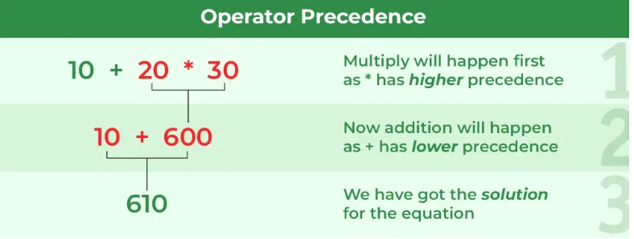

Exemplo de precedência de operadores. Fonte: [geeksforgeeks.org](https://www.geeksforgeeks.org/operator-precedence-and-associativity-in-c/)

Exemplos:

- `1 + 2 * -2` ➡ `1 + (2 * (-2))`
- `i + j * k` ➡ `i + (j * k)`
- `-i * -j` ➡ `(-i) * (-j)`

E quando uma expressão tem 2 operações com a mesma precedência?

```c
i - j + k

i / j * k
```

Tem-se em conta a associatividade.

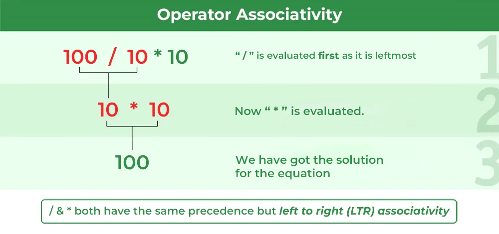

Exemplo de associatividade de operadores. Fonte: [geeksforgeeks.org](https://www.geeksforgeeks.org/operator-precedence-and-associativity-in-c/)

`i / j * k` == `(i / j) * k`

`+ - * / %` têm associtividade à esquerda, logo agrupam o que está antes do operador.

Os operadores unários têm associatividade à direita.

`- -2` == `- (-2)`

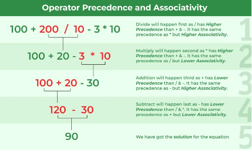

Exemplo de associatividade e precedência de operadores. Fonte: [geeksforgeeks.org](https://www.geeksforgeeks.org/operator-precedence-and-associativity-in-c/)

## Operadores de atribuição

Já conhecemos o operador de atribuição simples `=`.

É o que designamos por uma operação com **efeitos secundários**, porque altera o estado dos operandos.

`a = 2` altera o estado da variável `a` porque o seu valor é agora 2.

Adicionalmente, `a = 2` é uma expressão válida que devolve o valor que foi atribuido à variável

```c
int a=10;
printf("a=%d\n", a=2); // escreve 2 na consola e altera o valor de a
```

Todas as operações de atribuição exigem que o operando da esquerda seja uma variável.

Existem outros que se combinam com operações aritméticas.

| Expressão | Descrição |
| --- | --- |
| `var+=3` | soma 3 ao valor de var e atribui o resultado a var |
| `var-=3` | subtrai 3 ao valor de var e atribui o resultado a var |
| `var*=3` | multiplica 3 com o valor de var e atribui o resultado a var |
| `var/=3` | divide o valor de var por 3 e atribui o resultado a var |
| `var%=3` | faz o resto da divisão entre var e 3 e atribui o resultado a var |

- `v*=3` não é equivalente a `v = v * 3`, embora na maior parte das utilizações o resultado seja o mesmo. Porquê?
- Observem a expressão `v *= 3 + 10`. É equivalente a `v = v * 3 + 10`?
- Devido às regras de precedência e associatividade leva a um resultado diferente.

  ```c
  int a=3;
  printf("a=%d\n", (a = a * 3 + 10)); // a=19
  a=3;
  printf("a=%d\n", a*=3+10); // a=39
  ```

Não confundir `+=` com `=+`.

A primeira operação acumula o valor à direita.

A segunda é uma simples atribuição seguida do operador `+` unário.

Em suma…

… usem **sempre** `( )` para deixar claro qual é a ordem das operações.

## Incremento e decremento

Existe uma instrução que é frequentemente usada no C (irão perceber porquê quando abordarmos ciclos):

```c
i = i + 1;
i += 1;
```

Existe outra forma de escrever esta instrução, com o operador de incremento `++`

```
i = i + 1;
i += 1;
i++;
```

Este operador pode ser usado tanto antes de uma variável (pré-incremento) como depois (pós-incremento).

Qual será a diferença?

```c
int i=10;
printf("%d\n", ++i); // ?
printf("%d\n", i);   // ?
i=10;
printf("%d\n", i++); // ?
printf("%d\n", i);   // ?
```

```c
int i=10;
printf("%d\n", ++i); // 11
printf("%d\n", i);   // 11
i=10;
printf("%d\n", i++); // 10
printf("%d\n", i);   // 11
```

Além do incremento `++`, também temos disponível o decremento `--`, que funciona da mesma forma, mas subtrai em uma unidade.

## Avaliação de expressões

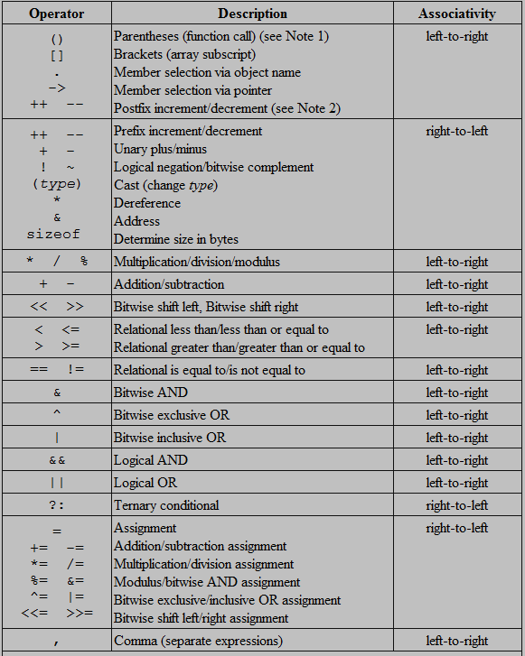

Resumo das operações que já vimos (clicar para ampliar).

Com este conhecimento conseguimos avaliar expressões complicadas.

`a= b += c++ - d + --e / -f`

1. Encontrar o operador com maior precedência.
2. Colocar ( ) à volta do operador e operandos.
   1. Aplicar regras de precedência e associatividade.
3. Repetir.

`a= b += c++ - d + --e / -f`

1. `a= b += (c++) - d + (--e) / -f` `c++` e depois `--e` (precedência)
2. `a= b += (c++) - d + (--e) / (-f)` operador unário `-f` (precedência)
3. `a= b += (c++) - d + ((--e) / (-f))` divisão (precedência)
3. `a= b += (c++) - d + ((--e) / (-f))`
4. `a= b += ((c++) - d) + ((--e) / (-f))` `-` e `+` com a mesma precedência e com operando em comum `d` (precedência), agrupam da esquerda para a direita, logo `-` primeiro (associatividade)
5. `a= b += (((c++) - d) + ((--e) / (-f)))` `+` (precedência)
6. `a= (b += (((c++) - d) + ((--e) / (-f))))` `=` e `+=` com mesma precedência (precedência), agrupam da direita para a esquerda, logo `+=` primeiro (associatividade)
7. `(a= (b += (((c++) - d) + ((--e) / (-f)))))` sobra apenas o `=` (precedência)

Moral da história: façam um favor a vós próprios…

. . .

… e usem `( )`.